# Coding exercise for ‘Exploration of AI Tools’

Yongjin Choi (LSHTM, Yongjin.Choi@lshtm.ac.uk)

2024-08-05

**Objectives**

- Provide practical experience in implementing a boosting algorithm manually, without relying on pre-built libraries;
- Gain a clear understanding of the basic principles behind machine learning, particularly how a boosting algorithm combines multiple weak classifiers to create a strong classifier; and
- Recognize the potential limitations and challenges of boosting algorithms, such as sensitivity to noisy data and overfitting.

**Note**

Please note that machine learning using perceptual measures can be very sensitive to respondents’ circumstances, emotions, and human biases. Ensuring that the models’ predictions align with actual human perceptions is challenging and requires rigorous validation and testing. Therefore, use this exercise only for learning purposes in class. In most cases, applying machine learning techniques to survey data based on perceptual measures is not considered a rigorous approach in science.

**To start**

In this exercise, you will create an R Markdown (RMD) file on your machine and replicate the code in this instruction. Follow these steps to set up your R Markdown notebook.

- Open RStudio.
- Click on `File` > `New File` > `R Markdown...`.
- Select `HTML` as the output format.
- Click `OK`
- General shortcuts
  - Run Current Chunk: `Ctrl + Alt + Enter` (Windows/Linux) or `Cmd + Option + C` (Mac)
  - Insert New Chunk: `Ctrl + Alt + I` (Windows/Linux) or `Cmd + Option + I` (Mac)

## 1. Basic settings

### Description

This section loads the required packages.

### Loading Packages

```r
# Updating packages
#update.packages(ask = FALSE)

# Loading packages
packages <- c("tidyverse", "fastDummies", "haven", "RCurl",
              "summarytools", "epiDisplay",
              "rpart", "mboost")
for (package in packages) {
  if (package %in% rownames(installed.packages()) == FALSE) {
    install.packages(package)
    library(package, character.only = TRUE)
  } else {
    library(package, character.only = TRUE)
  }
}
```

Back to top

## 2. Exercise 1: Manual boosting

### Description

Boosting is a powerful ensemble technique that combines the predictions of several weak classifiers to develop a stronger classifier. In this exercise, we will manually implement a simple boosting algorithm in R to understand its underlying mechanics. Boosting works by training a sequence of weak learners (typically a decision stump), each trying to correct the errors of its predecessor. The final model is a weighted sum of these weak learners.  
**TRY YOUR BEST NOT TO LOOK INTO ‘SOLUTION’ PAGE BEFORE COMPLETING THE ‘Exercise’ PAGE.**

### Data preparation

We will use a subset of the Vaccine Confidence Index data and will try to predict booster vaccine uptake for COVID-19 (vaxboost). This dataset includes a deidentified sample of 4,368 respondents from nine countries. The data was collected during the COVID-19 pandemic. The survey included COVID-19 vaccination, vaccine confidence, and other variables that may influence people’s confidence in vaccines and decisions to get a vaccine. The codebook is avaiable at: [link](https://lshtm-my.sharepoint.com/:x:/g/personal/lshyc4_lshtm_ac_uk/EZZe-_n5VstMvhDoCanyxJoBRh5mi0GUWVVFtNoEWhQohg?e=Pv4m1l)

```r
# Load the dataset
fileloc <- "https://raw.githubusercontent.com/TheYongjinChoi/croucher-2024/69b8f398f5982c8364c6a25efe138ce2d6f31eb4/vci.csv"
df <- read.csv(fileloc)

# Creating variables
train <- df %>%
  mutate(vaxboost = ifelse(covidvax == 3, 1,
                           ifelse(covidvax <= 2, 0,
                                  ifelse(covidvax == 4, 0, NA))),
         vaxboost = as.factor(vaxboost)) %>%
  select(vaxboost,
         gender, cntry, urban, age, edu, job,
         trhcp, health, covidrisk) %>%
  dummy_cols(select_columns = c("cntry", "age", "job"), remove_first_dummy = T, remove_selected_columns = T)

# Remove NAs
train <- na.omit(train)
```

Back to top

### Exercise

In this exercise, you will create a decision stump using the rpart package in R to perform binary classification and calculate the accuracy of the model’s predictions. You have a data frame `train` with the binary target variable `vaxboost` and various predictor variables. Follow these steps to complete the exercise.

##### Splitting data

- Extract the target variable and the predictor variables and save them to `y` and `xtrain`

```r
# Extract the target variable
y <- _____$_____

# Extract the predictor variables
xtrain <- subset(_____, select = -vaxboost)
```

##### Create the first decision stump

- Use the `rpart` function to create a decision stump `stump` (see the [usage](https://www.rdocumentation.org/packages/rpart/versions/4.1.23/topics/rpart))
- Limit the depth of the tree to 1 using the `maxdepth` parameter to ensure it’s a stump
- Set the complexity parameter `cp` to 0 to avoid pruning

```r
# Train the decision stump
stump <- _____(y ~ ., data = _____, maxdepth = __, cp = __)
```

##### Make predictions

- Use the trained model `stump` to make predictions on the predictor dataframe
- Set `type = "class"` to convert predicted probabilities to binary outcomes (0 or 1). Note that the default threshold is 0.5
- Use the `predict` function (see the [usage](https://www.rdocumentation.org/packages/car/versions/3.1-2/topics/Predict))
- Calculate the accuracy as the proportion of correct predictions and check the calculated accuracy

```r
# Make predictions
pred <- _____(_____, _____, type = "class")

# Calculate accuracy
accuracy <- sum(pred == _____) / nrow(_____)
print(paste("Accuracy:", accuracy))
```

##### Extract the residuals

- Extract the residuals from the stump and fit a second stump on it. Calculate the residuals, which are the differences between the actual values and the predictions from the first stump

```r
residuals <- as.numeric(as.character(y)) - predict(_____, _____, type = "vector")
```

##### Create the second decision stump

- Use the residuals as the new target variable and fit a second decision stump

```r
# Train the second decision stump on residuals
stump2 <- rpart(_____ ~ ., data = _____, maxdepth = 1, cp = 0)
```

##### Cumulate predictions

- Combine the predictions from both stumps
- Calculate the accuracy. Is it improved?

```r
# Cumulate predictions from both stumps
pred2 <- predict(_____, _____, type = "vector") + predict(_____, _____, type = "vector")

# Calculate accuracy
binary_pred <- ifelse(_____ > 0.5, 1, 0)
accuracy <- sum(_____ == y) / nrow(train)
print(paste("Accuracy:", accuracy))
```

##### Boosting algorithm

Now, we will iterate 100 times over this process by integrating it in a for loop.

- To start,initialize the number of iterations, cumulative predictions, and residuals.
- Create a vector to store accuracy at each iteration.

```r
# Initialize variables
M <- 100
Ffinal <- rep(0, nrow(train))  # Initialize cumulative predictions
r <- y  # Assign y to residuals

# Store successive accuracies
accuracies <- vector("numeric", M)
```

- Loop through the boosting process for `M` iterations.
- Apply a decision stump to the residuals.
- Update the cumulative predictions.
- Calculate and store the accuracy at each iteration.
- Update the residuals

```r
for (m in 1:M) {
  # Apply stump
  stump <- _____(__ ~ ., data = _____, maxdepth = 1, cp = 0)

  # Make prediction
  fm <- predict(_____, _____, type = "vector")

  # Update cumulative prediction
  Ffinal <- Ffinal + _____

  # Convert cumulative predictions to binary outcomes
  binary_pred <- ifelse(_____ > 0.5, 1, 0)

  # Compute accuracy
  accuracies[m] <- sum(_____ == y) / nrow(xtrain)

  # Update pseudo-response/residuals
  r <- as.numeric(as.character(y)) - Ffinal
  # residuals <- as.numeric(as.character(y)) - predict(stump, xtrain, type = "vector")

  print(paste0("Iteration: ", m))
}
```

##### Visualization

- Plot the accuracy for each iteration to visualize the performance of the boosting algorithm

```r
# Plot accuracies
plot(accuracies, type = "b", pch = 16, col = "darkgreen", ylab = "Training Accuracy", xlab = "Iteration")
```

Back to top

### Solution

In this exercise, you will create a decision stump using the rpart package in R to perform binary classification and calculate the accuracy of the model’s predictions. You have a data frame `train` with the binary target variable `vaxboost` and various predictor variables. Follow these steps to complete the exercise.

##### Splitting data

- Extract the target variable and the predictor variables and save them to `y` and `xtrain`

```r
# Extract the target variable
y <- train$vaxboost

# Extract the predictor variables
xtrain <- subset(train, select = -vaxboost)
```

##### Create the first decision stump

- Use the `rpart` function to create a decision stump `stump` (see the [usage](https://www.rdocumentation.org/packages/rpart/versions/4.1.23/topics/rpart))
- Limit the depth of the tree to 1 using the `maxdepth` parameter to ensure it’s a stump
- Set the complexity parameter `cp` to 0 to avoid pruning

```r
# Train the decision stump
stump <- rpart(y ~ ., data = xtrain, maxdepth = 1, cp = 0)
```

##### Make predictions

- Use the trained model `stump` to make predictions on the predictor dataframe
- Set `type = "class"` to convert predicted probabilities to binary outcomes (0 or 1). Note that the default threshold is 0.5
- Use the `predict` function (see the [usage](https://www.rdocumentation.org/packages/car/versions/3.1-2/topics/Predict))
- Calculate the accuracy as the proportion of correct predictions and check the calculated accuracy

```r
# Make predictions
pred <- predict(stump, xtrain, type = "class")

# Calculate accuracy
accuracy <- sum(pred == train$vaxboost) / nrow(train)
print(paste("Accuracy:", accuracy))
```

```
[1] "Accuracy: 0.57196261682243"
```

##### Extract the residuals

- Extract the residuals from the stump and fit a second stump on it. Calculate the residuals, which are the differences between the actual values and the predictions from the first stump

```r
residuals <- as.numeric(as.character(y)) - predict(stump, xtrain, type = "vector")
```

##### Create the second decision stump

- Use the residuals as the new target variable and fit a second decision stump

```r
# Train the second decision stump on residuals
stump2 <- rpart(residuals ~ ., data = xtrain, maxdepth = 1, cp = 0)
```

##### Cumulate predictions

- Combine the predictions from both stumps
- Calculate the accuracy. Is it improved?

```r
# Cumulate predictions from both stumps
pred2 <- predict(stump, xtrain, type = "vector") + predict(stump2, xtrain, type = "vector")

# Calculate accuracy
binary_pred <- ifelse(pred2 > 0.5, 1, 0)
accuracy <- sum(binary_pred == y) / nrow(train)
print(paste("Accuracy:", accuracy))
```

```
[1] "Accuracy: 0.645327102803738"
```

##### Boosting algorithm

Now, we will iterate 100 times over this process by integrating it in a for loop.

- To start,initialize the number of iterations, cumulative predictions, and residuals.
- Create a vector to store accuracy at each iteration.

```r
# Initialize variables
M <- 100
Ffinal <- rep(0, nrow(train))  # Initialize cumulative predictions
r <- y  # Assign y to residuals

# Store successive accuracies
accuracies <- vector("numeric", M)
```

- Loop through the boosting process for `M` iterations.
- Apply a decision stump to the residuals.
- Update the cumulative predictions.
- Calculate and store the accuracy at each iteration.
- Update the residuals

```r
for (m in 1:M) {
  # Apply stump
  stump <- rpart(r ~ ., data = xtrain, maxdepth = 1, cp = 0)

  # Make prediction
  fm <- predict(stump, xtrain, type = "vector")

  # Update cumulative prediction
  Ffinal <- Ffinal + fm

  # Convert cumulative predictions to binary outcomes
  binary_pred <- ifelse(Ffinal > 0.5, 1, 0)

  # Compute accuracy
  accuracies[m] <- sum(binary_pred == y) / nrow(xtrain)

  # Update pseudo-response/residuals
  r <- as.numeric(as.character(y)) - Ffinal
  # residuals <- as.numeric(as.character(y)) - predict(stump, xtrain, type = "vector")

  print(paste0("Iteration: ", m))
}
```

```
[1] "Iteration: 1"
[1] "Iteration: 2"
[1] "Iteration: 3"
[1] "Iteration: 4"
[1] "Iteration: 5"
[1] "Iteration: 6"
[1] "Iteration: 7"
[1] "Iteration: 8"
[1] "Iteration: 9"
[1] "Iteration: 10"
[1] "Iteration: 11"
[1] "Iteration: 12"
[1] "Iteration: 13"
[1] "Iteration: 14"
[1] "Iteration: 15"
```

[output cut: 85 more lines]

##### Visualization

- Plot the accuracy for each iteration to visualize the performance of the boosting algorithm

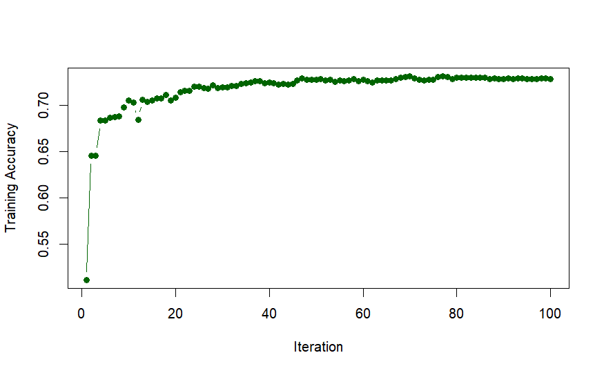

```r
# Plot accuracies
plot(accuracies, type = "b", pch = 16, col = "darkgreen", ylab = "Training Accuracy", xlab = "Iteration")
```

Back to top

## 3. Exercise 2: Boosting with an available package

### Description

In this exercise, we will use the `mboost` package in R to implement AdaBoost for binary classification. You have a data frame `train` with the binary target variable `vaxboost`.  
**TRY YOUR BEST NOT TO LOOK INTO ‘SOLUTION’ PAGE BEFORE COMPLETING THE ‘Exercise’ PAGE.**

### Exercise

##### Implement AdaBoost with `glmboost`

- Use the `glmboost` function to fit an AdaBoost model to the training data (see the [usage](https://www.rdocumentation.org/packages/GAMBoost/versions/1.2-3/topics/GLMBoost))
- Specify the family as `AdaExp()` for the AdaBoost exponential loss function

```r
# Fit the AdaBoost model
linboost <- _____(_____ ~ ., family = _____(), data = train)
```

##### Extract and analyze boosting coefficients:

- Extract the cumulative boosting coefficients by using `coef` and `do.call`
- Convert the coefficients to a readable format and display them

```r
# Extract cumulative boosting coefficients
boostcoefs <- _____(linboost, aggregate = "cumsum") |>
  _____(what = rbind) |> t()
colnames(boostcoefs) <- names(coef(linboost, aggregate = "cumsum"))
boostcoefs
```

##### Fit the AdaBoost model with a specified number of boosting iterations

- Fit an AdaBoost model with the `glmboost` function, specifying the number of boosting iterations using `control = boost_control(mstop = 1000)`

```r
# Fit AdaBoost model with specified number of boosting iterations
adaboost <- _____(_____ ~ ., data = _____, family = _____(), control = boost_control(mstop = 1000))
```

##### Perform cross-validation

- Define the cross-validation folds
- Perform cross-validation using the cvrisk function
- Plot the cross-validation results to visualize the model performance using `plot`

```r
# Define cross-validation folds
foldsada <- cv(model.weights(adaboost), type = "kfold")

# Perform cross-validation
cvresada <- cvrisk(adaboost, folds = foldsada)

# Plot cross-validation results
plot(cvresada)
```

Back to top

### Solution

##### Implement AdaBoost with `glmboost`

- Use the `glmboost` function to fit an AdaBoost model to the training data (see the [usage](https://www.rdocumentation.org/packages/GAMBoost/versions/1.2-3/topics/GLMBoost))
- Specify the family as `AdaExp()` for the AdaBoost exponential loss function

```r
(linboost <- glmboost(vaxboost ~ ., family = AdaExp(), data = train))
```

```
     Generalized Linear Models Fitted via Gradient Boosting

Call:
glmboost.formula(formula = vaxboost ~ ., data = train, family = AdaExp())


     Adaboost Exponential Error

Loss function: exp(-y * f)


Number of boosting iterations: mstop = 100
Step size:  0.1
Offset:  0.02243367

Coefficients:
 (Intercept)       gender          edu        trhcp      cntry_3      cntry_6      cntry_8     cntry_11        age_4        age_5       age_99        job_4        job_8
 0.176397310 -0.019230359 -0.002357230 -0.004100979  0.266903450 -0.053245296 -0.726074981 -1.394749363  0.014290341  0.179843786  0.233553621 -0.130244977 -0.073959438
attr(,"offset")
[1] 0.02243367
```

##### Extract and analyze boosting coefficients:

- Extract the cumulative boosting coefficients by using `coef` and `do.call`
- Convert the coefficients to a readable format and display them

```r
boostcoefs <- coef(linboost, aggregate = "cumsum") |>
  do.call(what = rbind) |> t()
colnames(boostcoefs) <- names(coef(linboost, aggregate = "cumsum"))
boostcoefs
```

```
       (Intercept)      gender           edu         trhcp    cntry_3     cntry_6    cntry_8   cntry_11      age_4      age_5     age_99       job_4       job_8
  [1,] 0.006636484  0.00000000  0.0000000000  0.0000000000 0.00000000  0.00000000  0.0000000 -0.1052006 0.00000000 0.00000000 0.00000000  0.00000000  0.00000000
  [2,] 0.015286796  0.00000000  0.0000000000  0.0000000000 0.00000000  0.00000000 -0.0761797 -0.1052006 0.00000000 0.00000000 0.00000000  0.00000000  0.00000000
  [3,] 0.021330062  0.00000000  0.0000000000  0.0000000000 0.00000000  0.00000000 -0.0761797 -0.2009975 0.00000000 0.00000000 0.00000000  0.00000000  0.00000000
  [4,] 0.029187449  0.00000000  0.0000000000  0.0000000000 0.00000000  0.00000000 -0.1453764 -0.2009975 0.00000000 0.00000000 0.00000000  0.00000000  0.00000000
  [5,] 0.034729040  0.00000000  0.0000000000  0.0000000000 0.00000000  0.00000000 -0.1453764 -0.2888420 0.00000000 0.00000000 0.00000000  0.00000000  0.00000000
  [6,] 0.041886140  0.00000000  0.0000000000  0.0000000000 0.00000000  0.00000000 -0.2084061 -0.2888420 0.00000000 0.00000000 0.00000000  0.00000000  0.00000000
  [7,] 0.046997169  0.00000000  0.0000000000  0.0000000000 0.00000000  0.00000000 -0.2084061 -0.3698613 0.00000000 0.00000000 0.00000000  0.00000000  0.00000000
  [8,] 0.053531527  0.00000000  0.0000000000  0.0000000000 0.00000000  0.00000000 -0.2659514 -0.3698613 0.00000000 0.00000000 0.00000000  0.00000000  0.00000000
  [9,] 0.058268454  0.00000000  0.0000000000  0.0000000000 0.00000000  0.00000000 -0.2659514 -0.4449503 0.00000000 0.00000000 0.00000000  0.00000000  0.00000000
 [10,] 0.062651250  0.00000000  0.0000000000  0.0000000000 0.00000000  0.00000000 -0.2659514 -0.5144258 0.00000000 0.00000000 0.00000000  0.00000000  0.00000000
 [11,] 0.068663800  0.00000000  0.0000000000  0.0000000000 0.00000000  0.00000000 -0.3189014 -0.5144258 0.00000000 0.00000000 0.00000000  0.00000000  0.00000000
 [12,] 0.072761557  0.00000000  0.0000000000  0.0000000000 0.00000000  0.00000000 -0.3189014 -0.5793828 0.00000000 0.00000000 0.00000000  0.00000000  0.00000000
 [13,] 0.078265259  0.00000000  0.0000000000  0.0000000000 0.00000000  0.00000000 -0.3673703 -0.5793828 0.00000000 0.00000000 0.00000000  0.00000000  0.00000000
 [14,] 0.072937610  0.00000000  0.0000000000  0.0000000000 0.04750487  0.00000000 -0.3673703 -0.5793828 0.00000000 0.00000000 0.00000000  0.00000000  0.00000000
```

[output cut: 63 more lines]

##### Fit the AdaBoost model with a specified number of boosting iterations

- Fit an AdaBoost model with the `glmboost` function, specifying the number of boosting iterations using `control = boost_control(mstop = 1000)`

```r
# Fit AdaBoost model with specified number of boosting iterations
adaboost <- glmboost(vaxboost ~ ., data = train, family = AdaExp(), control = boost_control(mstop = 1000))
```

##### Perform cross-validation

- Define the cross-validation folds
- Perform cross-validation using the cvrisk function
- Plot the cross-validation results to visualize the model performance using `plot`

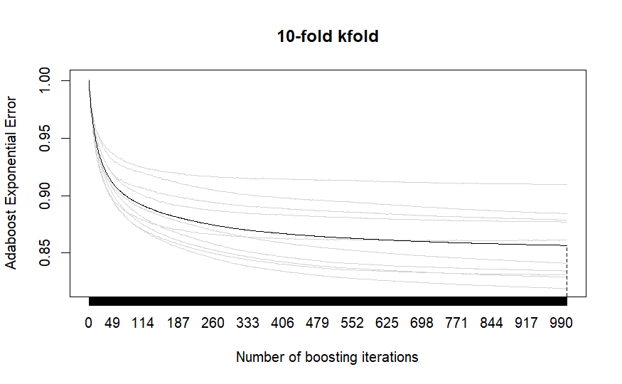

Back to top